# Install Packages

```python
!pip install scipy==1.7.1
```

[output not shown]

# Obtain A Dataset

Before we work through a statistical analysis, we first need to find a good dataset to explore. [Kaggle](https://www.kaggle.com/) is a great place to find interesting datasets!

We will be using the [Ramen Ratings](https://www.kaggle.com/residentmario/ramen-ratings/version/1?select=ramen-ratings.csv) dataset for our exercise today. Run the block below to download the dataset:

[figure not shown]

Photo by [Stephen Bedase](https://unsplash.com/@stephenkbedase?utm_source=unsplash&utm_medium=referral&utm_content=creditCopyText) on [Unsplash](https://unsplash.com/s/photos/ramen?utm_source=unsplash&utm_medium=referral&utm_content=creditCopyText)

```python
!wget https://s3.amazonaws.com/dev.sagardsaxena.com/RisingResearchers/statistics_module/ramen-ratings.csv
```

```
--2022-01-21 22:26:51--  https://s3.amazonaws.com/dev.sagardsaxena.com/RisingResearchers/statistics_module/ramen-ratings.csv
Resolving s3.amazonaws.com (s3.amazonaws.com)... 52.217.47.86
Connecting to s3.amazonaws.com (s3.amazonaws.com)|52.217.47.86|:443... connected.
HTTP request sent, awaiting response... 200 OK
Length: 169913 (166K) [text/csv]
Saving to: ‘ramen-ratings.csv’

ramen-ratings.csv   100%[===================>] 165.93K   656KB/s    in 0.3s

2022-01-21 22:26:52 (656 KB/s) - ‘ramen-ratings.csv’ saved [169913/169913]
```

If you click on the folder icon on the left, you should see a csv (comma-separated-values) file with the ramen ratings data.

# Read The Data

Now that we have downloaded the data, the next step is to read in the data to our Python notebook. We can do this in just a few lines of code with the Pandas library.

[figure not shown]

Photo by [Ying Wu](https://unsplash.com/@wuyyyying?utm_source=unsplash&utm_medium=referral&utm_content=creditCopyText) on [Unsplash](https://unsplash.com/s/photos/panda?utm_source=unsplash&utm_medium=referral&utm_content=creditCopyText)

```python
import pandas as pd

ramen_data = pd.read_csv('ramen-ratings.csv')
ramen_data.head()
```

|  | Unnamed: 0 | Review # | Brand | Variety | Style | Country | Stars | Top Ten |
| --- | --- | --- | --- | --- | --- | --- | --- | --- |
| 0 | 0 | 2580 | New Touch | T's Restaurant Tantanmen | Cup | Japan | 3.75 | NaN |
| 1 | 1 | 2579 | Just Way | Noodles Spicy Hot Sesame Spicy Hot Sesame Guan... | Pack | Taiwan | 1.00 | NaN |
| 2 | 2 | 2578 | Nissin | Cup Noodles Chicken Vegetable | Cup | USA | 2.25 | NaN |
| 3 | 3 | 2577 | Wei Lih | GGE Ramen Snack Tomato Flavor | Pack | Taiwan | 2.75 | NaN |
| 4 | 4 | 2576 | Ching's Secret | Singapore Curry | Pack | India | 3.75 | NaN |

# Data Exploration

We want to start by brainstorming some research questions about the data and then visualizing the trends in the data. Let's focus on treating the rating of ramen as a dependent variable and other variables as independent variables.

- What makes ramen have a higher rating?
  - Do certain brands have higher ratings than others?
  - Does ramen from certain countries have higher ratings than other countaries?
  - Do certain styles of ramen get higher ratings than others?
- Is the data biased?
  - Are certain brands overrepresented in the data?
  - Are certain countries overrepresented in the data?
  - Are certain styles overrepresented in the data?

## Data Bias

We want to make sure that our data isn't biased or that we are making sure to include that factor in our analysis. For example, if there are 100 ramen ratings for Japanese Ramen and only 1 ramen rating for US Ramen, we might want to avoid making generalizations about Ramen in the US.

[figure not shown]

Photo by [Elena Mozhvilo](https://unsplash.com/@miracleday?utm_source=unsplash&utm_medium=referral&utm_content=creditCopyText) on [Unsplash](https://unsplash.com/s/photos/justice?utm_source=unsplash&utm_medium=referral&utm_content=creditCopyText)

We can access a specific column of a dataset by using the `dataset[column]` syntax. Then, we can get the frequency of each value by using the `value_counts` command on a column and can limit this to only the top 10 values by adding `[:10]`

Finally, we can make a nice pie chart by using the `.plot().pie()` command on our top 10 values and thier frequencies.

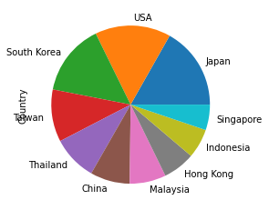

```python
country_data = ramen_data["Country"]
country_freq = country_data.value_counts()
country_freq_10 = country_freq[:10]
country_freq_10.plot.pie()
```

Even in just the top 10 countries, we can see that countries like Japan and the US have an oversized impact on the ramen ratings dataset.

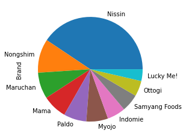

```python
country_data = ramen_data["Brand"]
country_freq = country_data.value_counts()
country_freq_10 = country_freq[:10]
country_freq_10.plot.pie()
```

In the top 10 brands, we can see that Nissin has the largest share of Ramen Ratings and that the first two brands make up 50% of all ratings from the top 10 brands.

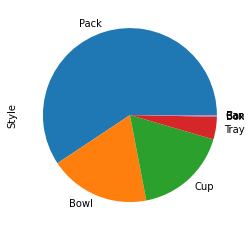

```python
country_data = ramen_data["Style"]
country_freq = country_data.value_counts()
country_freq_10 = country_freq[:10]
country_freq_10.plot.pie()
```

Pack Ramen is the key winner in having the most ramen ratings and makes up a big share of the data.

## Trends

[figure not shown]

Photo by [UX Indonesia](https://unsplash.com/@uxindo?utm_source=unsplash&utm_medium=referral&utm_content=creditCopyText) on [Unsplash](https://unsplash.com/s/photos/data?utm_source=unsplash&utm_medium=referral&utm_content=creditCopyText)

To look at how different indepenent variables (country, brand, style) have an effect on the rating of ramen, we can take an **aggregate** of the rating for each variable.

For example, we can use the **average** rating for Japanese Ramen and the **average** rating for US Ramen and compare the two to get an idea of how the rating might differ.

To do this, we should first filter our columns to only what we need. To do this, we can just extend the previous example by adding multiple column names

`dataset[[column1, column2, ...]]`

```python
style_stars_data = ramen_data[["Style", "Stars"]]
style_stars_data.head()
```

|  | Style | Stars |
| --- | --- | --- |
| 0 | Cup | 3.75 |
| 1 | Pack | 1.00 |
| 2 | Cup | 2.25 |
| 3 | Pack | 2.75 |
| 4 | Pack | 3.75 |

`groupby(by=[column_to_group_on]).mean()`

Finally, we can use a bar plot to visualize the different average ratings

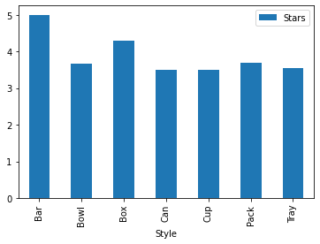

```python
style_stars_data = ramen_data[["Style", "Stars"]]
style_avg_stars = style_stars_data.groupby(by=["Style"]).mean()
style_avg_stars.plot.bar()
```

Since, we have too many countries and brands to visualize in a bar graph, let's limit the countries and brands to only the top 10.

We can replace `.mean()` with `.agg([aggregate1, aggregate2, ...])` which will allow us to both get the mean and count of each column.

```python
country_stars_data = ramen_data[["Country", "Stars"]]
country_avg_stars = country_stars_data.groupby(
    by=["Country"])["Stars"].agg(['mean', 'count'])
country_avg_stars.head()
```

| Country | mean | count |
| --- | --- | --- |
| Australia | 3.138636 | 22 |
| Bangladesh | 3.714286 | 7 |
| Brazil | 4.350000 | 5 |
| Cambodia | 4.200000 | 5 |
| Canada | 2.243902 | 41 |

Then, we can sort the rows by the count in descending order by using the `.sort_values(by="count", ascending=False)` and get the top 10 rows by using `[:10]` like before.

```python
country_avg_stars_10 = country_avg_stars.sort_values(
    by="count", ascending=False)[:10]
country_avg_stars_10.head()
```

| Country | mean | count |
| --- | --- | --- |
| Japan | 3.981605 | 352 |
| USA | 3.457043 | 323 |
| South Korea | 3.790554 | 307 |
| Taiwan | 3.665402 | 224 |
| Thailand | 3.384817 | 191 |

Finally, we can plot the average rating for each of the top ten countries:

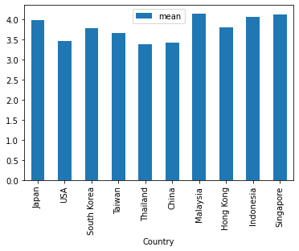

```python
country_avg_stars_10.plot.bar(y="mean")
```

Let's do the same with brands

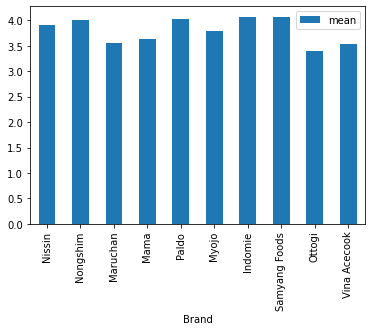

```python
brand_stars_data = ramen_data[["Brand", "Stars"]]
brand_avg_stars = brand_stars_data.groupby(
    by=["Brand"])["Stars"].agg(['mean', 'count'])
brand_avg_stars_10 = brand_avg_stars.sort_values(
    by="count", ascending=False).head(10)
brand_avg_stars_10.plot.bar(y="mean")
```

# Research Hypothesis

[figure not shown]

Photo by [Max Griss](https://unsplash.com/@grisskitchen?utm_source=unsplash&utm_medium=referral&utm_content=creditCopyText) on [Unsplash](https://unsplash.com/s/photos/ramen?utm_source=unsplash&utm_medium=referral&utm_content=creditCopyText)

After our data exploration, we saw a couple of different trends in the data. Now let's pose a hypothesis that we can either prove or disprove using a statistical analysis

```
H: There is a statistically significant difference between Japanese Ramen Ratings and US Ramen Ratings.
H_0: There is not a statistically significant difference between Japanese Ramen Ratings and US Ramen Ratings.
```

Let's first get only the ratings for Japan and USA. We can filter this down by using `ramen_ratings['Country'] == country` as an index

```python
japan_ratings = ramen_data[ramen_data['Country'] == 'Japan']["Stars"]
usa_ratings = ramen_data[ramen_data['Country'] == 'USA']["Stars"]
```

Now that we have both the ratings for Japan and USA, we can perform a statistical test to see whether or not there is a significant difference between ramen ratings in ramen from the two countries

We want to compare the mean score of USA ramen ratings with the mean score given to Japan ramen ratings. There are two main statistical tests used to compare means from two samples.

1. **Student's T-Test**
2. **Mann–Whitney U test**

The main difference between the two tests is that the Student's T-Test requires the data to be normally distributed, whereas the Mann-Whitney U Test does not have that requirement.

Here is an example of what the normal distribution looks like:

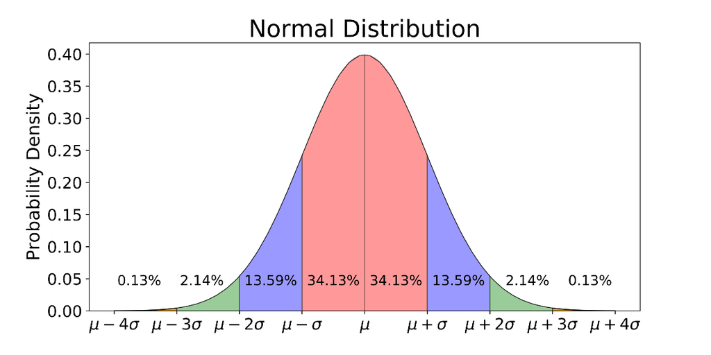

We can eyeball to see if our data are normal by graphing it. `matplotlib.pyplot` is a tool we can use to graph the data.

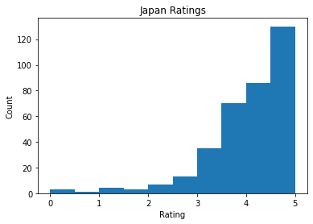

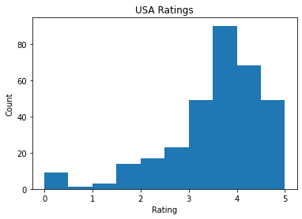

```python
import matplotlib.pyplot as plt

plt.hist(japan_ratings)
plt.title("Japan Ratings")
plt.xlabel("Rating")
plt.ylabel("Count")
plt.show()
plt.hist(usa_ratings)
plt.title("USA Ratings")
plt.xlabel("Rating")
plt.ylabel("Count")
plt.show()
```

The Scipy library provides us with a stats module that gives us tools to help us calculate p-values from our test

**One of the asumptions needed to use the t-test is normal distribution (i.e. a bell-shaped curve). Let's first verify that the samples are normally distributed ...**

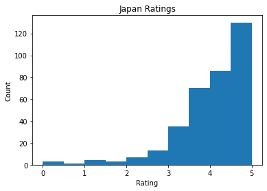

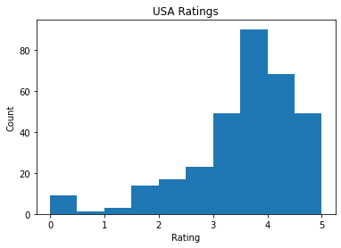

```python
import matplotlib.pyplot as plt

plt.hist(japan_ratings)
plt.title("Japan Ratings")
plt.xlabel("Rating")
plt.ylabel("Count")
plt.show()
plt.hist(usa_ratings)
plt.title("USA Ratings")
plt.xlabel("Rating")
plt.ylabel("Count")
plt.show()
```

```python
from scipy.stats import ttest_ind, mannwhitneyu
stat, p = ttest_ind(japan_ratings,usa_ratings)
print("p-value:", p)

stat, p = mannwhitneyu(japan_ratings,usa_ratings)
print("p-value:", p)
```

```
p-value: 1.0764593678983968e-11
p-value: 3.0115045766869164e-13
```

Since our p-value is below 0.05, we can reject the null hypothesis! We are (at least) 95% confident that there is a statistically significant difference between Japanese and US Ramen Ratings!

What if we modified our hypothesis slightly:

```
H: There is statistically significant evidence that Japanese Ramen is rated higher than US Ramen.
H_0: There is not statistically significant evidence that Japanese Ramen is rated higher than US Ramen.
```

```python
from scipy.stats import ttest_ind, mannwhitneyu
stat, p = ttest_ind(japan_ratings,usa_ratings, alternative="greater")
print("p-value:", p)

stat, p = mannwhitneyu(japan_ratings,usa_ratings, alternative="greater")
print("p-value:", p)
```

```
p-value: 5.382296839491984e-12
p-value: 1.5057522883434582e-13
```

Again, we can see that our p-value is below 0.05 and we can reject the null hypothesis! We are (at least) 95% confident that Japanese Ramen is rated higher than US Ramen!